# Laporan Survei Evaluasi dan Usulan Program Agen Perubahan 2023-2024

Zaky Nur Kusmantoro

2024-01-19

## Tujuan Evaluasi

Laporan evaluasi ini bertujuan sebagai tolak ukur keberhasilan melalui keefektifan setiap program, tingkat partisipasi pegawai pada kegiatan Agen Perubahan dan kinerja anggota agen perubahan. Selain itu, bertujuan untuk menilai kegiatan agen perubahan pada tahun 2023 yang menarik dan perlu dilanjutkan pada tahun 2024. Serta, masukan kegiatan agen perubahan tahun 2024 yang bisa dilaksanakan untuk membuat kegiatan agen perubahan lebih baik lagi

Survei ini dilaksanakan dari Rabu, 17 Januari 2024 - Jumat, 19 Januari 2024 dengan melibatkan 47 pegawai di Direktorat Standardaisasi Pangan Olahan. Pertanyaan yang disampaikan kepada pegawai adalah sebagai berikut:

1. **Menurut Anda, apakah implementasi program telah efektif dalam memberikan manfaat yang diinginkan?** Pada pertanyaan ini menilai untuk masing-masing program agen perubahan pada tahun 2023 dengan 4 skala penilaian (Sangat Tidak Efektif, Tidak Efektif, Efektif, dan Sangat Efektif). Pilihan *tidak tahu* juga tersedia untuk pegawai yang tidak mengetahui kegiatan tersebut
2. **Bagaimana tingkat partisipasi dan keterlibatan Anda pada program Agen Perubahan Direktorat SPO 2023?** Pada pertanyaan ini bertujuan untuk menilai persepsi partisipasi pegawai terhadap kegiatan agen perubahan pada tahun 2023 dengan 4 skala penilaian (Sangat Tinggi, Tinggi, Rendah, Sangat Rendah)
3. **Bagaimana penilaian Anda terhadap kinerja Agen Perubahan Direktorat SPO 2023?** Pada pertanyaan ini bertujuan untuk menilai kinerja agen perubahan pada tahun 2023 secara keseluruhan dengan 3 skala penilaian (Di bawah ekspektasi, Sesuai ekspektasi, dan Di atas ekspektasi)
4. **Pilihlah program Agen Perubahan Direktorat SPO 2023 yang paling menarik? (Silakan pilih 3 program)** dan **Menurut Anda, program Agen Perubahan Direktorat SPO 2023 apa saja yang perlu dilanjutkan pada tahun 2024? (Silakan pilih maksimal 3 program)** masing-masing untuk memilih program yang menarik di tahun 2023 dan perlu dilanjutkan pada tahun 2024
5. **Kritik** untuk kegiatan agen perubahan pada tahun 2023 dan **saran** untuk meningkatkan kinerja agen perubahan pada tahun 2024 terutama untuk nilai **Harmonis**

## Deskripsi Data

Pertama, akan dilihat terlebih dahulu deskripsi data yang akan dianalisis

```
## tibble [47 × 19] (S3: tbl_df/tbl/data.frame)
##  $ timestamp           : POSIXct[1:47], format: "2024-01-17 13:17:27" "2024-01-17 13:29:06" "2024-01-17 13:35:59" "2024-01-17 13:52:08" ...
##  $ nama                : chr [1:47] "Sentani Chasfila, S.Farm, Apt." "Erline Yuniarti, S.Farm.Apt., M.Si." "Zaky Nur Kusmantoro, S.Si" "Wahyu Linanto, S.Kom" ...
##  $ helpline_sobat_repa : chr [1:47] "Efektif" "Sangat Efektif" "Efektif" "Sangat Efektif" ...
##  $ rumah_repa          : chr [1:47] "Efektif" "Sangat Efektif" "Efektif" "Efektif" ...
##  $ monday_briefing_team: chr [1:47] "Efektif" "Sangat Efektif" "Sangat Efektif" "Sangat Efektif" ...
##  $ monevspo            : chr [1:47] "Efektif" "Sangat Efektif" "Efektif" "Sangat Efektif" ...
##  $ jumat_smart         : chr [1:47] "Efektif" "Sangat Efektif" "Efektif" "Sangat Efektif" ...
##  $ sehari_ceria        : chr [1:47] "Efektif" "Sangat Efektif" "Efektif" "Sangat Efektif" ...
##  $ fyi_spo             : chr [1:47] "Efektif" "Sangat Efektif" "Efektif" "Sangat Efektif" ...
##  $ we_move             : chr [1:47] "Efektif" "Sangat Efektif" "Tidak Efektif" "Sangat Efektif" ...
##  $ space_station       : chr [1:47] "Efektif" "Sangat Efektif" "Tidak Efektif" "Sangat Efektif" ...
##  $ portal_aoc          : chr [1:47] "Tidak tahu" "Sangat Efektif" "Tidak Efektif" "Sangat Efektif" ...
##  $ partisipasi         : chr [1:47] "Tinggi" "Sangat Tinggi" "Tinggi" "Sangat Tinggi" ...
##  $ kinerja             : chr [1:47] "Sesuai ekspektasi" "Di atas ekspektasi" "Sesuai ekspektasi" "Di atas ekspektasi" ...
##  $ program_menarik     : chr [1:47] "Rumah Repa, Monday Briefing Team, We Move" "Monday Briefing Team, Aplikasi MonevSPO, FYI SPO" "Monday Briefing Team, Aplikasi MonevSPO, Jumat Smart" "Helpline Sobat Repa, Monday Briefing Team, Jumat Smart" ...
##  $ program_lanjutan    : chr [1:47] "Helpline Sobat Repa, Rumah Repa, Sehari Ceria" "Rumah Repa, FYI SPO, SPACE Station" "Monday Briefing Team, Jumat Smart, Portal AoC" "Rumah Repa, Monday Briefing Team, Jumat Smart" ...
##  $ kritik_saran        : chr [1:47] "Sudah cukup baik" "Sudah bagus. Terimakasih karena sudah mendapat Juara 3." "lebih solid lagi (soliddddd) dan melibatkan seluruh pegawai dalam pelaksanaan yang mendukung AoC tersebut" "Sudah baik, tingkatkan" ...
##  $ usulan              : chr [1:47] "-" "SPACE Station di upgrade misal dengan stikerisasi terkait Berakhlak, Pojok  Foto, Monday briefing tim bisa diup"| __truncated__ "sudah disampaikan ya dalam forum" "- Harus ada anggaran untuk AoC, contoh rumah repa mau dibawa kemana? untuk konten membutuhka…
##  $ -                   : chr [1:47] "Gathering karyawan, gotong royong membersihkan ruangan, soalisasi indept terkait nilai nilai apa yg bisa ditera"| __truncated__ "seluruh pegawai lebih bisa membaur kembali dan mau ikut serta dalam kegiatan yang khususnya melibatkan AoC ters"| __truncated__ "- …
```

Jika dilihat dari output tersebut `tibble [47 x 19]` yang menandakan ada 47 baris dan 19 kolom pada data tersebut. 47 baris tersebut menandakan jumlah pegawai yang mengisi survei tersebut. Sementara 19 kolom adalah banyaknya variabel pertanyaan yang diajukan pada survei tersebut. `$ timetsamp` adalah nama variabel. Kemudian, `POSIXct[1:47]` adalah tipe data dari variabel `$ timestamp` dengan informasi dari baris ke 1 hingga 47. Selanjunya, diikuti dengan data yang terisi pada variabel tersebut.

## Analisis Data

Setelah diidentifikasi deskripsi data hasil survei evaluasi dan usulan program agen perubahan 2023-2024. Selanjutnya, akan dilakukan analisis data yang diperlukan untuk mengidentifikasi bagaimana implementasi program agen perubahan di tahun 2023, tingkat partisipasi dan keterlibatan pegawai terhadap kegiatan, kinerja agen perubahan, program agen perubahan yang menarik di tahun 2023 dan perlu dilanjutkan di tahun 2024

1. Implementasi Program Agen Perubahan Tahun 2023

   Sebelumnya dikategorikan terlebih dahulu urutan penilaian implementasi secara berurutan mulai dari **Sangat Efektif**, **Efektif**, **Tidak Efektif**, **Sangat Tidak Efektif**, dan **Tidak tahu**. Kemudian dibuat tabel kontingensi antara program agen perubahan dengan penilaian efektifitasnya

   ```
   ## # A tibble: 10 × 5
   ## # Groups:   kegiatan [10]
   ##    kegiatan             `Sangat Efektif` Efektif `Tidak Efektif` `Tidak tahu`
   ##    <chr>                           <int>   <int>           <int>        <int>
   ##  1 monevspo                           30      17              NA           NA
   ##  2 monday_briefing_team               21      23               3           NA
   ##  3 jumat_smart                        19      28              NA           NA
   ##  4 space_station                      18      21               4            4
   ##  5 fyi_spo                            14      28               1            4
   ##  6 sehari_ceria                       14      25               4            4
   ##  7 helpline_sobat_repa                12      29               3            3
   ##  8 we_move                            12      30               3            2
   ##  9 portal_aoc                         10      18               5           14
   ## 10 rumah_repa                          8      22               4           13
   ```

   Dari tabel tersebut, jika diurutkan dari jumlah keefektifan yang tinggi kegiatan **monevspo** merupakan kegiatan agen perubahan yang sangat efektif dengan perolehan 30 pegawai, kemudian selanjutnya diikuti oleh monday_briefing_team dengan perolehan 21 pegawai, dan posisi ketiga adalah **jumat_smart** dengan perolehan 19 pegawai
2. Tingkat Partisipasi dan Keterlibatan Pegawai terhadap Kegiatan Agen Perubahan

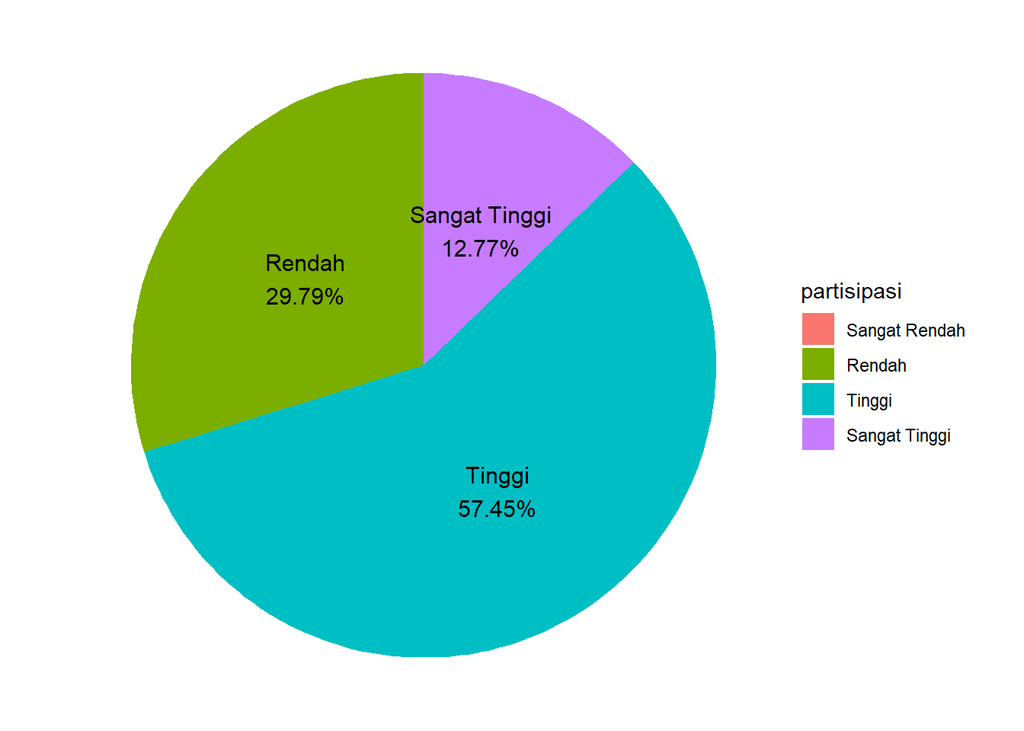

   ```
   ## # A tibble: 3 × 2
   ##   kinerja             Total
   ##   <fct>               <int>
   ## 1 Di bawah ekspektasi     0
   ## 2 Sesuai ekspektasi      22
   ## 3 Di atas ekspektasi     25
   ```

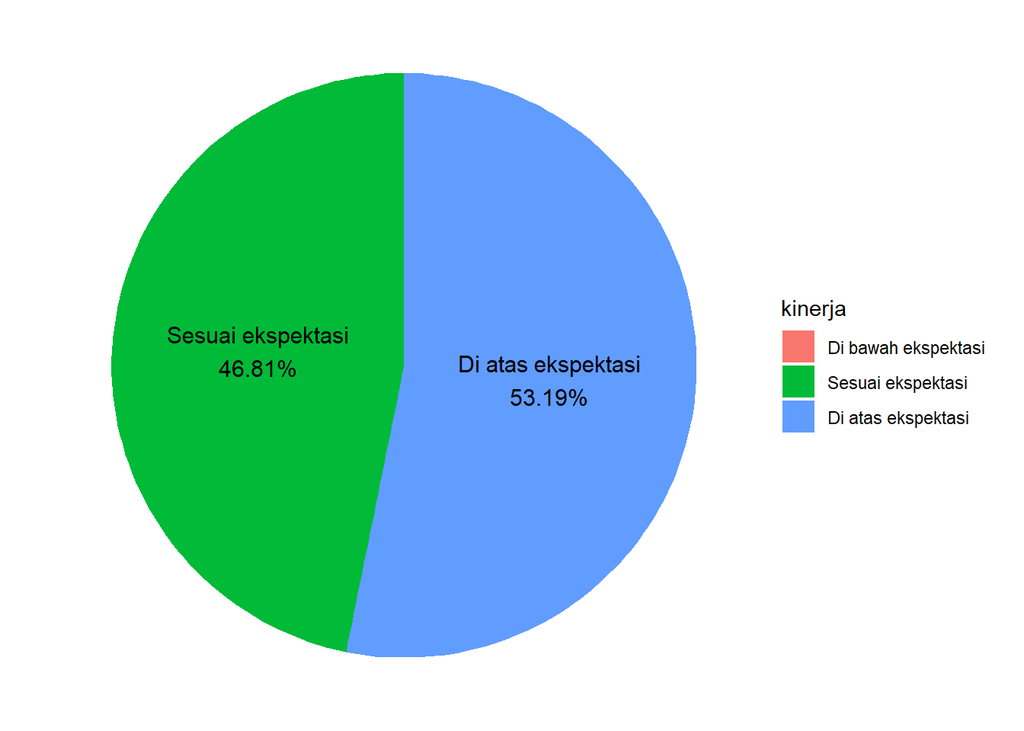

   Dari *pie chart* di atas penilaian untuk agen perubahan tahun 2023 tidak ada yang di bawah ekspektasi. Sekitar 46,81% atau 22 dari 47 pegawai menilai kinerja agen perubahan tahun 2023 sudah sesuai ekspektasi dan 53,19% atau 25 dari 47 pegawai menilai di atas ekspektasi
4. Program Agen Perubahan Terbaik dan Perlu Dilanjutkan

   ```
   ## # A tibble: 10 × 3
   ##    program_menarik      Menarik Dilanjutkan
   ##    <chr>                  <int>       <int>
   ##  1 Aplikasi MonevSPO         30          25
   ##  2 Monday Briefing Team      20          20
   ##  3 Helpline Sobat Repa       19          18
   ##  4 Jumat Smart               19          20
   ##  5 SPACE Station             16          16
   ##  6 We Move                   15           7
   ##  7 Rumah Repa                12          16
   ##  8 FYI SPO                    4           5
   ##  9 Sehari Ceria               4           6
   ## 10 Portal AoC                 2           3
   ```

   Untuk lebih memberikan informasi yang jelas apakah program agen perubahan yang menurut pegawai terbaik pada tahun 2023 perlu dilanjutkan kembali pada tahun 2024 akan dilihat korelasinya seperti berikut

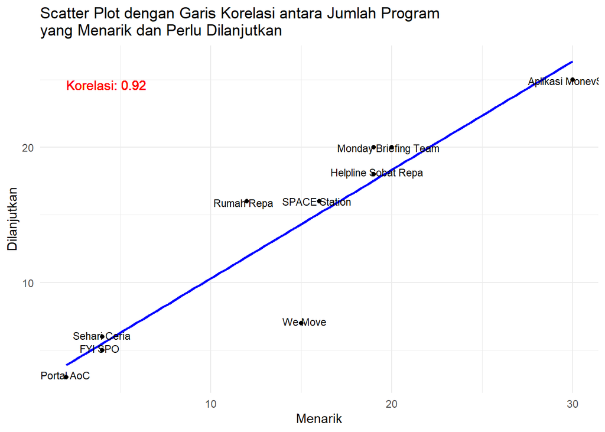

   Dari *output* tersebut terdapat korelasi yang kuat antara program yang menarik perlu dilanjutkan. Korelasi yang kuat tersebut berdasarkan nilai koefisian korelasi sebesar 0,92. Untuk lebih memperkuat kembali akan dilakukan analisis berdasarkan 4 kuadran dengan membagi dua garis vertikal dan horizontal yang berpotongan dan dihitung berdasarkan rata-ratanya

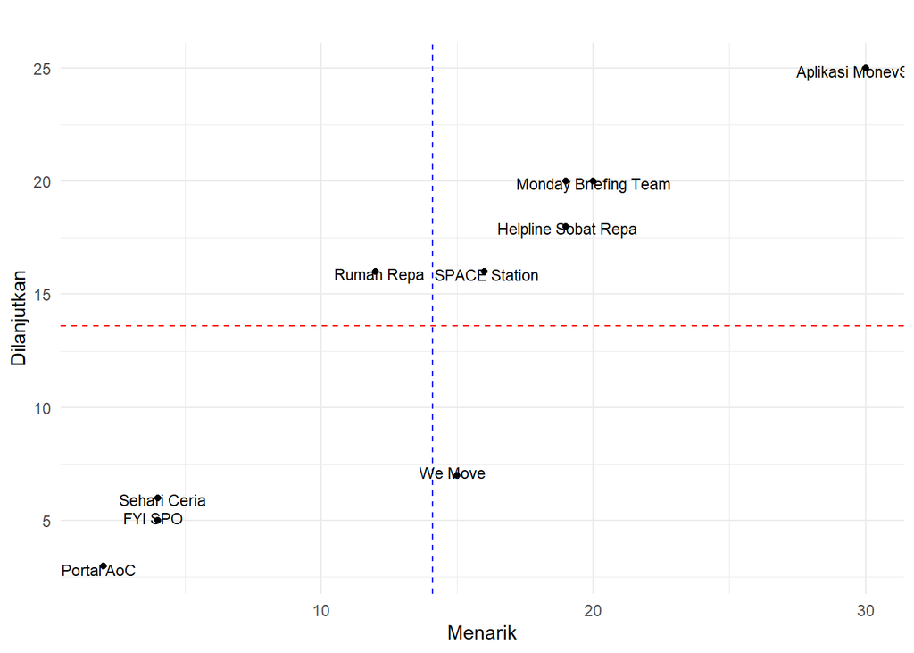

      Terdapat pada kuadran yang ada di sebelah kanan garis biru dan di bawah garis merah. Ada satu kegiatan perubahan yang menarik tetapi tidak perlu dilanjutkan yaitu **We Move**
   3. Kegiatan yang Kurang Menarik tetapi Perlu Dilanjutkan

      Terdapat pada kuadran yang ada di sebelah kiri garis biru dan di atas garis merah. Ada satu kegiatan perubahan yaitu **Rumah Repa**
   4. Kegiatan yang Kurang Menarik dan Tidak Perlu Dilanjutkan

      Terdapat pada kuadran yang ada di sebelah kiri garis biru dan di bawah garis merah, yaitu kegiatan yang kurang menarik dan tidak perlu dilanjutkan kembali **Sehari Ceria**, **FYI SPO**, dan **Portal AoC**
5. Kritik dan Saran

   Kritik dan Saran secara umum digunakan untuk menilai kinerja agen perubahan pada tahun 2023 serta harapan perbaikan untuk agen perubahan di tahun 2024. Untuk melihat sentimen dari kritik dan saran pegawai akan digunakan metode dengan `wordcloud` yaitu suatu metode representasi visual dari frekuensi kata dalam teks, di mana kata-kata yang lebih sering muncul akan di-*highlight* lebih besar, seperti berikut:

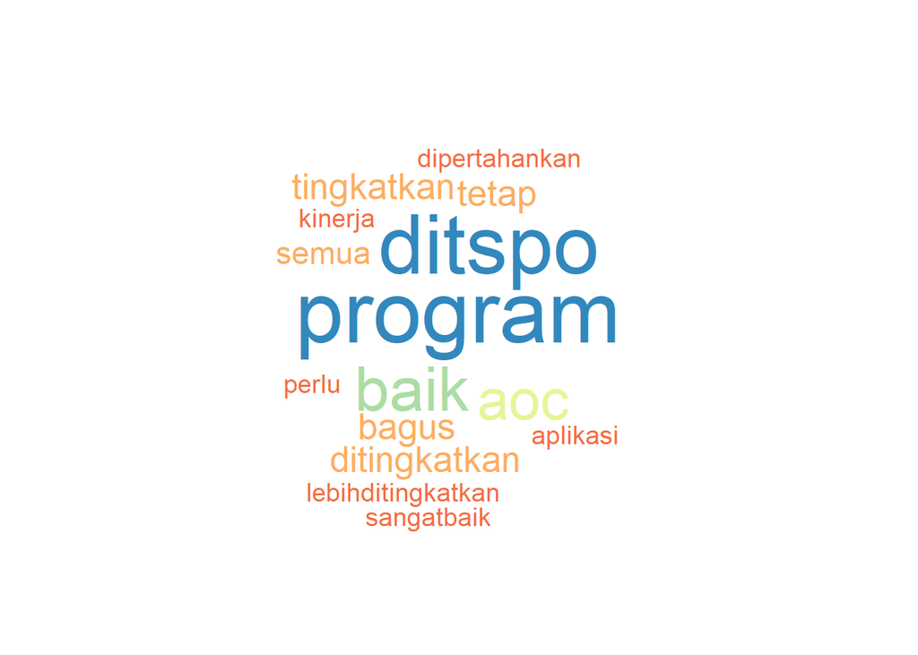

   Dari gambar tersebut, muncul kata-kata yang sering muncul dari kritik dan saran, seperti **program**, **aoc**, **baik**, **ditingkatkan**,**dipertahankan**, **sangat baik**, dan sebagainya. Sehingga dapat disimpulkan kinerja agen perubahan sudah bagus dan perlu ditingkatkan kembali kualitasnya.

   Selain itu, agen perubahan juga memerlukan saran perbaikan terutama pada penilaian **Harmonis** dan **Loyal** yang masih rendah, serta usulan kegiatan di tahun 2024 terlampir sebagai berikut

   **1. Usulan Kegiatan Agen Perubahan Tahun 2024**

   | Usulan Kegiatan Agen Perubahan Tahun 2024 |
   | --- |
   | - |
   | SPACE Station di upgrade misal dengan stikerisasi terkait Berakhlak, Pojok Foto, Monday briefing tim bisa diupgrade misal menjadi I love monday, jadi diharapkan setiap orang di SPO selalu menanti nant… |
   | sudah disampaikan ya dalam forum |
   | - Harus ada anggaran untuk AoC, contoh rumah repa mau dibawa kemana? untuk konten membutuhkan anggaran agar menjadi lebih menarik - Study banding ke unit yang telah menjadi WBBM - Buat program yang as… |
   | Vidio Sosialisasi peraturan pangan olahan melalui media sosial (DISAPA) |
   | Belum ada ide |
   | mensosialisasikan atau berbagi ilmu yang didapat dari workshop atau pelatihan dari luar untuk teman2 yang lain |
   | Aplikasi penentuan kategori pangan |
   | Monthly gathering Dit SPO |
   | program yang mengarah ke hidup lebih sehat, misal video peregangan setiap jam 10, |

   [output cut: 37 more lines]

   **2. Saran Peningkatan Nilai Harmonis dan Loyal**

   | Usulan yang Mempengaruhi Nilai Loyal dan Harmonis |
   | --- |
   | Gathering karyawan, gotong royong membersihkan ruangan, soalisasi indept terkait nilai nilai apa yg bisa diterapkan untuk harmonis dan loyal |
   | seluruh pegawai lebih bisa membaur kembali dan mau ikut serta dalam kegiatan yang khususnya melibatkan AoC tersebut selama itu baik untuk semua |
   | - Mengadakan family gathering untuk pegawai dit SPO untuk meningkatkan hamonisasi..dimulai dari keluarga agar saling mengenal yang kedepannya lebih harmonis ke pekerjaan. - Beri apresiasi untuk pegawa… |
   | Membuat program untuk meningkatkan engagement antar pegawai dengan mengedepankan empati |
   | Menerapkan nilai berakhlak pada sehari² ... |
   | dalam membangun keharmonisan dan loyalitas bisa dengan saling tolong menolong, saling berkomunikasi dengan baik, dengan makan siang bersama menjalin komunikasi, saling menghargai dan memberikan komuni… |
   | Meningkatkan kegiatan engagement internal. |
   | Mengadakan pertemuan tatap muka dg semua asn Dit SPO utk kegiatan kebersamaan minimal 1 kali dlm 1 bulan |
   | banyak melakukan kegiatan bersama |
   | Peningkatan engagement staf SPO: Liwetan bareng, lomba antar subdit yang tidak terkait dengan pekerjaan hehe (cerdas cermat, dll) |

   [output cut: 37 more lines]

## Kesimpulan

   Dari beberapa pembahasan analisis yang telah dilakukan dapat diambil kesimpulan
   1. Untuk kegiatan agen perubahan tahun 2023 yang sangat efektif menurut pegawai di Dit. SPO adalah **monevspo** dengan 30 pegawai berpendapat kegiatan tersebut sangat efektif saat pelaksanaannya. Kemudian, ditempat kedua ada **monday_briefing_team** dan di tempat ketiga ada **jumat_smart**
   2. Tingkat partisipasi pegawai terhadap kegiatan agen perubahan tahun 2023 57,45% dari 47 pegawai adalah tinggi, diikuti 12,77% dari 47 pegawai berpartisiasi sangat tinggi, dan masih ada 29,79% dari 47 pegawai yang rendah
   3. Kinerja agen perubahan tahun 2023 sudah di atas ekspektasi, terlihat sudah di atas 50% atau 53,19% dari 47 pegawai
   4. Beberapa program agen perubahan tahun 2023 ada yang perlu dipertimbangkan untuk diajukan kembali menjadi kegiatan di tahun 2024 seperti **Aplikasi MonevSPO**, **Monday Briefing Team**, **Jum’at Smart**, **Helpline Sobat Repa**, dan **SPACE Station**
   5. Kritik dan Saran untuk agen perubahan adalah perlu dipertahankan kinerja yang sudah ada dan perlu ditingkatkan kembali kualitasnya, tentunya dengan pertimbangan usulan dan harapan dari seluruh pegawai Direktorat Standardisasi Pangan Olahan

   Demikian disampaikan, atas perhatiannya diucapkan terima kasih.